# Airline Delay & Flight Analytics Project

## STEP 1 : IMPORT LIBRARIES

```python
import pandas as pd
import numpy as np
import matplotlib.pyplot as plt
import seaborn as sns
```

## STEP 2 : LOADING DATASET

```python
df = pd.read_csv("flights.csv")
```

## STEP 3 : BASIC DATA INSPECTION

## 1) Head

Displays the first 5 rows of the dataset.

```python
df.head()
```

|  | YEAR | MONTH | DAY | DAY_OF_WEEK | AIRLINE | FLIGHT_NUMBER | TAIL_NUMBER | ORIGIN_AIRPORT | DESTINATION_AIRPORT | SCHEDULED_DEPARTURE | ... | ARRIVAL_TIME | ARRIVAL_DELAY | DIVERTED | CANCELLED | CANCELLATION_REASON | AIR_SYSTEM_DELAY | SECURITY_DELAY | AIRLINE_DELAY | LATE_AIRCRAFT_DELAY | WEATHER_DELAY |
| --- | --- | --- | --- | --- | --- | --- | --- | --- | --- | --- | --- | --- | --- | --- | --- | --- | --- | --- | --- | --- | --- |
| 0 | 2015 | 1 | 1 | 4 | AS | 98 | N407AS | ANC | SEA | 5 | ... | 408.0 | -22.0 | 0 | 0 | NaN | NaN | NaN | NaN | NaN | NaN |
| 1 | 2015 | 1 | 1 | 4 | AA | 2336 | N3KUAA | LAX | PBI | 10 | ... | 741.0 | -9.0 | 0 | 0 | NaN | NaN | NaN | NaN | NaN | NaN |
| 2 | 2015 | 1 | 1 | 4 | US | 840 | N171US | SFO | CLT | 20 | ... | 811.0 | 5.0 | 0 | 0 | NaN | NaN | NaN | NaN | NaN | NaN |
| 3 | 2015 | 1 | 1 | 4 | AA | 258 | N3HYAA | LAX | MIA | 20 | ... | 756.0 | -9.0 | 0 | 0 | NaN | NaN | NaN | NaN | NaN | NaN |
| 4 | 2015 | 1 | 1 | 4 | AS | 135 | N527AS | SEA | ANC | 25 | ... | 259.0 | -21.0 | 0 | 0 | NaN | NaN | NaN | NaN | NaN | NaN |

5 rows × 31 columns

## 2) info()

Displays dataset information. Shows:

Column names

Number of non-null values

Data types

Memory usage

```python
df.info()
```

```
<class 'pandas.core.frame.DataFrame'>
RangeIndex: 5819079 entries, 0 to 5819078
Data columns (total 31 columns):
 #   Column               Dtype
---  ------               -----
 0   YEAR                 int64
 1   MONTH                int64
 2   DAY                  int64
 3   DAY_OF_WEEK          int64
 4   AIRLINE              object
 5   FLIGHT_NUMBER        int64
 6   TAIL_NUMBER          object
 7   ORIGIN_AIRPORT       object
 8   DESTINATION_AIRPORT  object
 9   SCHEDULED_DEPARTURE  int64
```

[output cut: 23 more lines]

## 3) shape

Shows number of rows and columns.

```python
df.shape
```

```
(5819079, 31)
```

## 4) decribe()

Shows statistical summary of numerical columns.

It shows:

Count

Mean

Standard deviation

Minimum value

Maximum value

Quartiles (25%, 50%, 75%)

```python
df.describe()
```

[output not shown]

8 rows × 31 columns

```python
print(data.duplicated().sum())
```

```
0
```

## 5) columns

Columns is used to display the names of all columns in the dataset.

```python
df.columns
```

```
Index(['YEAR', 'MONTH', 'DAY', 'DAY_OF_WEEK', 'AIRLINE', 'FLIGHT_NUMBER',
       'TAIL_NUMBER', 'ORIGIN_AIRPORT', 'DESTINATION_AIRPORT',
       'SCHEDULED_DEPARTURE', 'DEPARTURE_TIME', 'DEPARTURE_DELAY', 'TAXI_OUT',
       'WHEELS_OFF', 'SCHEDULED_TIME', 'ELAPSED_TIME', 'AIR_TIME', 'DISTANCE',
       'WHEELS_ON', 'TAXI_IN', 'SCHEDULED_ARRIVAL', 'ARRIVAL_TIME',
       'ARRIVAL_DELAY', 'DIVERTED', 'CANCELLED', 'CANCELLATION_REASON',
       'AIR_SYSTEM_DELAY', 'SECURITY_DELAY', 'AIRLINE_DELAY',
       'LATE_AIRCRAFT_DELAY', 'WEATHER_DELAY'],
      dtype='object')
```

## 8) unique()

unique() is used to display all unique (distinct) values in a column.

```python
df['AIRLINE'].unique()
```

```
array(['AS', 'AA', 'US', 'DL', 'NK', 'UA', 'HA', 'B6', 'OO', 'EV', 'MQ',
       'F9', 'WN', 'VX'], dtype=object)
```

## STEP 4 : DATA CLEANING

### HANDlE MISSING VALUES

### checking missing value

```python
df.isnull().sum()
```

```
YEAR                         0
MONTH                        0
DAY                          0
DAY_OF_WEEK                  0
AIRLINE                      0
FLIGHT_NUMBER                0
TAIL_NUMBER              14721
ORIGIN_AIRPORT               0
DESTINATION_AIRPORT          0
SCHEDULED_DEPARTURE          0
DEPARTURE_TIME           86153
DEPARTURE_DELAY          86153
TAXI_OUT                 89047
WHEELS_OFF               89047
SCHEDULED_TIME               6
ELAPSED_TIME            105071
AIR_TIME                105071
DISTANCE                     0
WHEELS_ON                92513
TAXI_IN                  92513
SCHEDULED_ARRIVAL            0
ARRIVAL_TIME             92513
ARRIVAL_DELAY           105071
DIVERTED                     0
CANCELLED                    0
CANCELLATION_REASON    5729195
AIR_SYSTEM_DELAY       4755640
SECURITY_DELAY         4755640
AIRLINE_DELAY          4755640
LATE_AIRCRAFT_DELAY    4755640
WEATHER_DELAY          4755640
dtype: int64
```

```python
# Remove rows with missing delays
df = df[df['ARRIVAL_DELAY'].notnull()]
df = df[df['DEPARTURE_DELAY'].notnull()]

# Fill delay causes
delay_cols = [
    'AIR_SYSTEM_DELAY','SECURITY_DELAY',
    'AIRLINE_DELAY','LATE_AIRCRAFT_DELAY','WEATHER_DELAY'
]
df[delay_cols] = df[delay_cols].fillna(0)

# Fill categorical
df['CANCELLATION_REASON'] = df['CANCELLATION_REASON'].fillna('Not Cancelled')
df['TAIL_NUMBER'] = df['TAIL_NUMBER'].fillna('Unknown')

# Fill small numeric gaps
df['SCHEDULED_TIME'] = df['SCHEDULED_TIME'].fillna(df['SCHEDULED_TIME'].median())

# Optional fills
df['TAXI_IN'] = df['TAXI_IN'].fillna(0)
df['TAXI_OUT'] = df['TAXI_OUT'].fillna(0)
df['AIR_TIME'] = df['AIR_TIME'].fillna(0)
df['ELAPSED_TIME'] = df['ELAPSED_TIME'].fillna(0)
```

```python
df.isnull().sum()
```

```
YEAR                   0
MONTH                  0
DAY                    0
DAY_OF_WEEK            0
AIRLINE                0
FLIGHT_NUMBER          0
TAIL_NUMBER            0
ORIGIN_AIRPORT         0
DESTINATION_AIRPORT    0
SCHEDULED_DEPARTURE    0
DEPARTURE_TIME         0
DEPARTURE_DELAY        0
TAXI_OUT               0
WHEELS_OFF             0
SCHEDULED_TIME         0
ELAPSED_TIME           0
AIR_TIME               0
DISTANCE               0
WHEELS_ON              0
TAXI_IN                0
SCHEDULED_ARRIVAL      0
ARRIVAL_TIME           0
ARRIVAL_DELAY          0
DIVERTED               0
CANCELLED              0
CANCELLATION_REASON    0
AIR_SYSTEM_DELAY       0
SECURITY_DELAY         0
AIRLINE_DELAY          0
LATE_AIRCRAFT_DELAY    0
WEATHER_DELAY          0
dtype: int64
```

### CHECKING DUPLICATION

```python
df.duplicated()
```

```
0          False
1          False
2          False
3          False
4          False
           ...
5819074    False
5819075    False
5819076    False
5819077    False
5819078    False
Length: 5714008, dtype: bool
```

```python
print(df.duplicated().sum())
```

```
0
```

### CHECKING DATATYPES AND OPTIMIZING MEMORY

```python
df.dtypes
```

```
YEAR                     int64
MONTH                    int64
DAY                      int64
DAY_OF_WEEK              int64
AIRLINE                 object
FLIGHT_NUMBER            int64
TAIL_NUMBER             object
ORIGIN_AIRPORT          object
DESTINATION_AIRPORT     object
SCHEDULED_DEPARTURE      int64
DEPARTURE_TIME         float64
DEPARTURE_DELAY        float64
TAXI_OUT               float64
WHEELS_OFF             float64
SCHEDULED_TIME         float64
ELAPSED_TIME           float64
AIR_TIME               float64
DISTANCE                 int64
WHEELS_ON              float64
TAXI_IN                float64
SCHEDULED_ARRIVAL        int64
ARRIVAL_TIME           float64
ARRIVAL_DELAY          float64
DIVERTED                 int64
CANCELLED                int64
CANCELLATION_REASON     object
AIR_SYSTEM_DELAY       float64
SECURITY_DELAY         float64
AIRLINE_DELAY          float64
LATE_AIRCRAFT_DELAY    float64
WEATHER_DELAY          float64
dtype: object
```

```python
df['AIRLINE'] = df['AIRLINE'].astype('category')
df['ORIGIN_AIRPORT'] = df['ORIGIN_AIRPORT'].astype('category')
df['DESTINATION_AIRPORT'] = df['DESTINATION_AIRPORT'].astype('category')
df['TAIL_NUMBER'] = df['TAIL_NUMBER'].astype('category')
df['CANCELLATION_REASON'] = df['CANCELLATION_REASON'].astype('category')
```

```python
df['YEAR'] = df['YEAR'].astype('int16')
df['MONTH'] = df['MONTH'].astype('int8')
df['DAY'] = df['DAY'].astype('int8')
df['DAY_OF_WEEK'] = df['DAY_OF_WEEK'].astype('int8')

df['FLIGHT_NUMBER'] = df['FLIGHT_NUMBER'].astype('int32')
df['DISTANCE'] = df['DISTANCE'].astype('int16')

df['DIVERTED'] = df['DIVERTED'].astype('int8')
df['CANCELLED'] = df['CANCELLED'].astype('int8')
```

```python
float_cols = [
    'DEPARTURE_DELAY','TAXI_OUT','WHEELS_OFF',
    'SCHEDULED_TIME','ELAPSED_TIME','AIR_TIME',
    'WHEELS_ON','TAXI_IN','ARRIVAL_TIME',
    'ARRIVAL_DELAY','AIR_SYSTEM_DELAY','SECURITY_DELAY',
    'AIRLINE_DELAY','LATE_AIRCRAFT_DELAY','WEATHER_DELAY'
]

df[float_cols] = df[float_cols].astype('float32')
```

```python
df['DEP_HOUR'] = (df['DEPARTURE_TIME'] // 100).astype('Int8')
df['ARR_HOUR'] = (df['ARRIVAL_TIME'] // 100).astype('Int8')
```

```python
df.info()
```

```
<class 'pandas.core.frame.DataFrame'>
Index: 5714008 entries, 0 to 5819078
Data columns (total 33 columns):
 #   Column               Dtype
---  ------               -----
 0   YEAR                 int16
 1   MONTH                int8
 2   DAY                  int8
 3   DAY_OF_WEEK          int8
 4   AIRLINE              category
 5   FLIGHT_NUMBER        int32
 6   TAIL_NUMBER          category
 7   ORIGIN_AIRPORT       category
 8   DESTINATION_AIRPORT  category
 9   SCHEDULED_DEPARTURE  int64
```

[output cut: 25 more lines]

## STEP 5 : FEATURE ENGINEERING

#### Total Delay

```python
df['TOTAL_DELAY'] = df['DEPARTURE_DELAY'] + df['ARRIVAL_DELAY']
```

#### Delay Status

```python
def delay_status(x):
    if x <= 0:
        return "On-Time"
    elif x <= 15:
        return "Minor Delay"
    else:
        return "Major Delay"

df['DELAY_STATUS'] = df['ARRIVAL_DELAY'].apply(delay_status)
```

#### Weekend Flag

```python
df['IS_WEEKEND'] = df['DAY_OF_WEEK'].apply(lambda x: 1 if x in [6,7] else 0)
```

#### Peakhour Analysis

```python
def peak_hour(x):
    if 6 <= x < 12:
        return "Morning"
    elif 12 <= x < 18:
        return "Afternoon"
    elif 18 <= x < 24:
        return "Evening"
    else:
        return "Night"

df['TIME_OF_DAY'] = df['DEP_HOUR'].apply(peak_hour)
```

#### On-time Flag

```python
df['ON_TIME'] = df['ARRIVAL_DELAY'].apply(lambda x: 1 if x <= 0 else 0)
```

#### Route

```python
df['ROUTE'] = df['ORIGIN_AIRPORT'].astype(str) + " - " + df['DESTINATION_AIRPORT'].astype(str)
```

```python
df.info()
```

```
<class 'pandas.core.frame.DataFrame'>
Index: 5714008 entries, 0 to 5819078
Data columns (total 39 columns):
 #   Column               Dtype
---  ------               -----
 0   YEAR                 int16
 1   MONTH                int8
 2   DAY                  int8
 3   DAY_OF_WEEK          int8
 4   AIRLINE              category
 5   FLIGHT_NUMBER        int32
 6   TAIL_NUMBER          category
 7   ORIGIN_AIRPORT       category
 8   DESTINATION_AIRPORT  category
 9   SCHEDULED_DEPARTURE  int64
```

[output cut: 31 more lines]

## STEP 6 : EDA (EXPLORATORY DATA ANALYSIS)

### 1. Total Flights

```python
print("Total Flights:", len(df))
```

```
Total Flights: 5714008
```

### 2. Delay Distribution

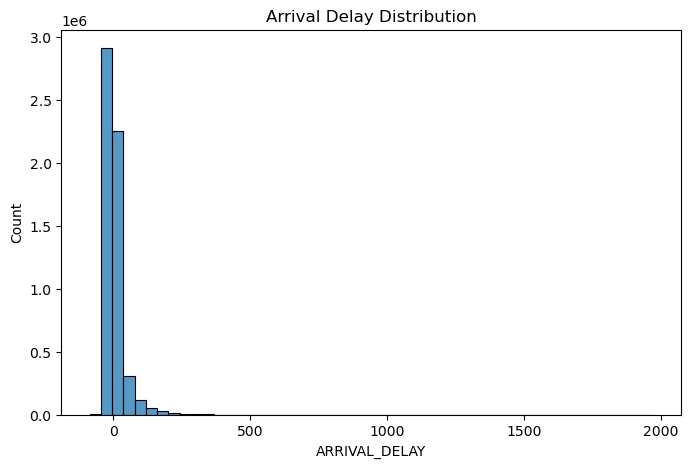

```python
plt.figure(figsize=(8,5))
sns.histplot(df['ARRIVAL_DELAY'], bins=50)
plt.title("Arrival Delay Distribution")
plt.show()
```

### 3. Airline Performance

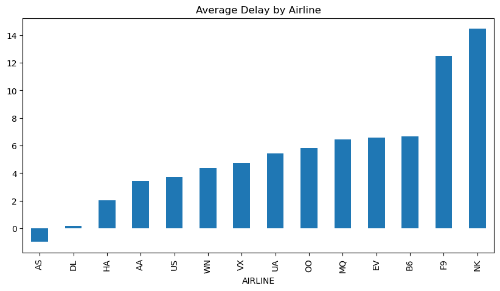

```python
airline_delay = df.groupby('AIRLINE', observed=False)['ARRIVAL_DELAY'].mean().sort_values()

airline_delay.plot(kind='bar', figsize=(10,5))
plt.title("Average Delay by Airline")
plt.show()
```

### 4. Monthly Delay Trend

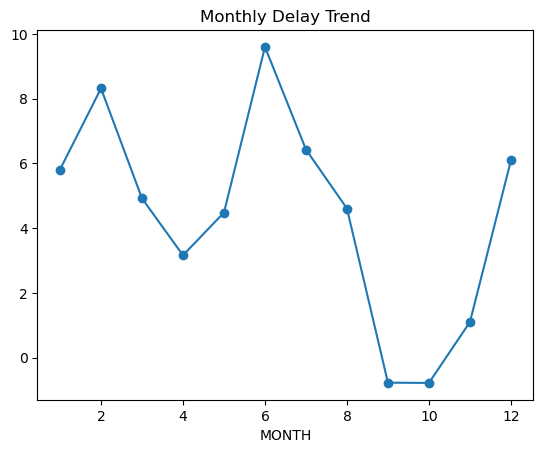

```python
monthly_delay = df.groupby('MONTH')['ARRIVAL_DELAY'].mean()

monthly_delay.plot(marker='o')
plt.title("Monthly Delay Trend")
plt.show()
```

### 5. Peak hour analysis

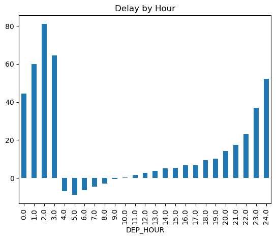

```python
df['DEP_HOUR'] = (df['DEPARTURE_TIME'] // 100)

hour_delay = df.groupby('DEP_HOUR')['ARRIVAL_DELAY'].mean()

hour_delay.plot(kind='bar')
plt.title("Delay by Hour")
plt.show()
```